# Homework 2

# 2 Exploring credit card fraud

```
## Rows: 671,028
## Columns: 14
## $ trans_date_trans_time <dttm> 2019-02-22 07:32:58, 2019-02-16 15:07:20, 2019-…
## $ trans_year            <dbl> 2019, 2019, 2019, 2019, 2019, 2019, 2019, 2020, …
## $ category              <chr> "entertainment", "kids_pets", "personal_care", "…
## $ amt                   <dbl> 7.79, 3.89, 8.43, 40.00, 54.04, 95.61, 64.95, 3.…
## $ city                  <chr> "Veedersburg", "Holloway", "Arnold", "Apison", "…
## $ state                 <chr> "IN", "OH", "MO", "TN", "CO", "GA", "MN", "AL", …
## $ lat                   <dbl> 40.1186, 40.0113, 38.4305, 35.0149, 39.4584, 32.…
## $ long                  <dbl> -87.2602, -80.9701, -90.3870, -85.0164, -106.385…
## $ city_pop              <dbl> 4049, 128, 35439, 3730, 277, 1841, 136, 190178, …
## $ job                   <chr> "Development worker, community", "Child psychoth…
## $ dob                   <date> 1959-10-19, 1946-04-03, 1985-03-31, 1991-01-28,…
## $ merch_lat             <dbl> 39.41679, 39.74585, 37.73078, 34.53277, 39.95244…
## $ merch_long            <dbl> -87.52619, -81.52477, -91.36875, -84.10676, -106…
## $ is_fraud              <dbl> 0, 0, 0, 0, 0, 0, 0, 0, 0, 0, 0, 0, 0, 0, 0, 0, …
```

The data dictionary is as follows

| column(variable) | description |
| --- | --- |
| trans_date_trans_time | Transaction DateTime |
| trans_year | Transaction year |
| category | category of merchant |
| amt | amount of transaction |
| city | City of card holder |
| state | State of card holder |
| lat | Latitude location of purchase |
| long | Longitude location of purchase |
| city_pop | card holder’s city population |
| job | job of card holder |
| dob | date of birth of card holder |
| merch_lat | Latitude Location of Merchant |
| merch_long | Longitude Location of Merchant |
| is_fraud | Whether Transaction is Fraud (1) or Not (0) |

- In this dataset, how likely are fraudulent transactions? Generate a table that summarizes the number and frequency of fraudulent transactions per year.

```r
library(dplyr)
library(tidyr)

view(card_fraud)

# Calculate the likelihood of fraudulent transactions
fraud_likelihood <- card_fraud %>%
  group_by(trans_year,is_fraud) %>%
  count() %>%
  group_by(trans_year) %>%
  mutate(Total_Transactions = sum(n), Percentage_fraudulent = n / Total_Transactions * 100) %>%
  filter(is_fraud == 1) %>%
  print
```

```
## # A tibble: 2 × 5
## # Groups:   trans_year [2]
##   trans_year is_fraud     n Total_Transactions Percentage_fraudulent
##        <dbl>    <dbl> <int>              <int>                 <dbl>
## 1       2019        1  2721             478646                 0.568
## 2       2020        1  1215             192382                 0.632
```

- How much money (in US$ terms) are fraudulent transactions costing the company? Generate a table that summarizes the total amount of legitimate and fraudulent transactions per year and calculate the % of fraudulent transactions, in US$ terms.

```r
fraud_cost <- card_fraud %>%
  group_by(trans_year) %>%
  filter(is_fraud == 1) %>%
  summarise(total_loss = paste("$",sum(amt))) %>%
  print()
```

```
## # A tibble: 2 × 2
##   trans_year total_loss
##        <dbl> <chr>
## 1       2019 $ 1423140.01
## 2       2020 $ 651949.18
```

```r
# Generate a table summarizing total legitimate and fraudulent transactions per year
transaction_summary <- card_fraud %>%
  group_by(trans_year, is_fraud) %>%
  summarise(total_amount = sum(amt)) %>%
  pivot_wider(names_from = is_fraud, values_from = total_amount, names_prefix = "total_") %>%
  mutate(Percentage_fraud = total_1 / (total_0 + total_1) * 100)
print(transaction_summary)
```

```
## # A tibble: 2 × 4
## # Groups:   trans_year [2]
##   trans_year   total_0  total_1 Percentage_fraud
##        <dbl>     <dbl>    <dbl>            <dbl>
## 1       2019 32182901. 1423140.             4.23
## 2       2020 12925914.  651949.             4.80
```

- Generate a histogram that shows the distribution of amounts charged to credit card, both for legitimate and fraudulent accounts. Also, for both types of transactions, calculate some quick summary statistics.

```r
# Filter the dataframe for legitimate and fraudulent transactions separately
legitimate <- card_fraud %>% filter(is_fraud == 0)
fraudulent <- card_fraud %>% filter(is_fraud == 1)

# Create a histogram for legitimate transactions
leg_hist <- ggplot(legitimate, aes(x = amt)) +
  geom_histogram(binwidth = 100) +
  labs(title = "Distribution of Amounts Charged (Legitimate)",
       x = "Amount",
       y = "Frequency")

# Create a histogram for fraudulent transactions
fraud_hist <- ggplot(fraudulent, aes(x = amt)) +
  geom_histogram(binwidth = 100) +
  labs(title = "Distribution of Amounts Charged (Fraudulent)",
       x = "Amount",
       y = "Frequency")

# Calculate summary statistics for legitimate transactions
leg_summary <- legitimate %>%
  summarise(min_amt = min(amt),
            max_amt = max(amt),
            median_amt = median(amt),
            mean_amt = mean(amt))

# Calculate summary statistics for fraudulent transactions
fraud_summary <- fraudulent %>%
  summarise(min_amt = min(amt),
            max_amt = max(amt),
            median_amt = median(amt),
            mean_amt = mean(amt))

# Print the summary statistics
print(leg_summary)
```

```
## # A tibble: 1 × 4
##   min_amt max_amt median_amt mean_amt
##     <dbl>   <dbl>      <dbl>    <dbl>
## 1       1  27120.       47.2     67.6
```

```r
print(fraud_summary)
```

```
## # A tibble: 1 × 4
##   min_amt max_amt median_amt mean_amt
##     <dbl>   <dbl>      <dbl>    <dbl>
## 1    1.06   1334.       369.     527.
```

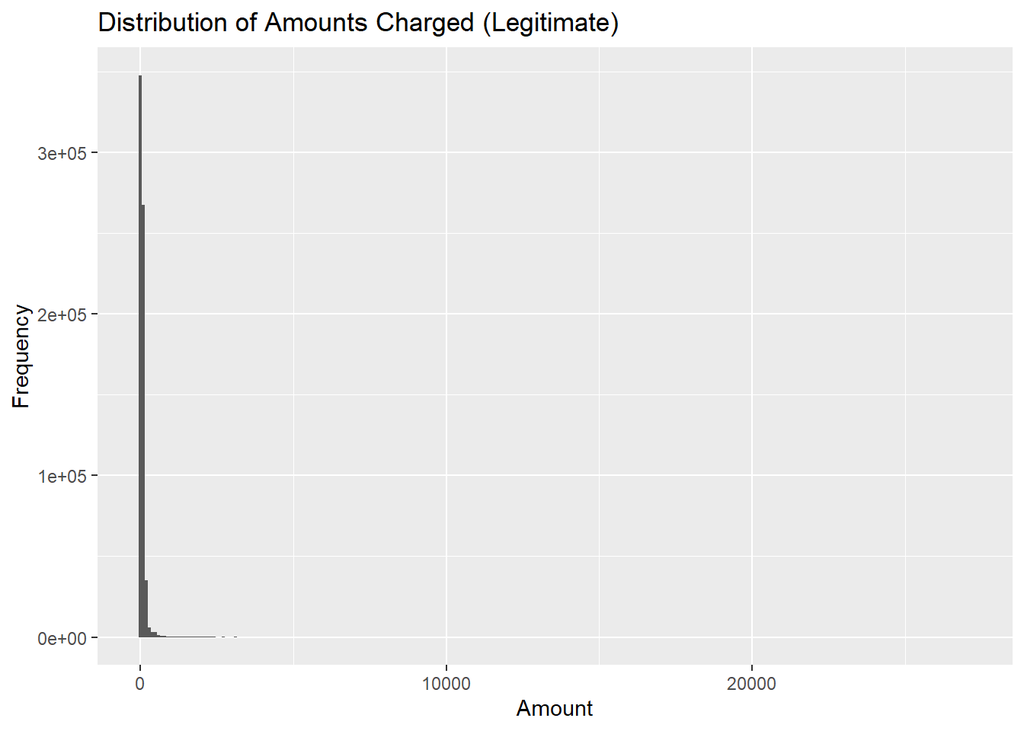

```r
# Display the histograms
print(leg_hist)
```

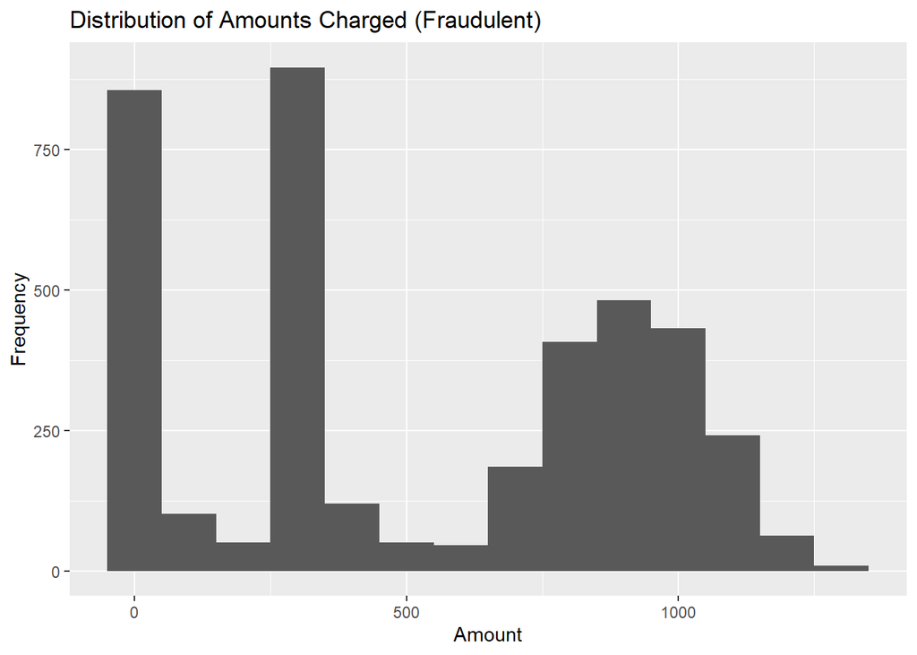

```r
print(fraud_hist)
```

- What types of purchases are most likely to be instances of fraud? Consider category of merchants and produce a bar chart that shows % of total fraudulent transactions sorted in order.

```r
# Calculate the percentage of total fraudulent transactions for each category
fraud_category <- fraudulent %>%
  group_by(category) %>%
  summarise(total_fraud = n()) %>%
  mutate(percentage = (total_fraud / sum(total_fraud)) * 100) %>%
  arrange(desc(percentage))

# Create a bar chart showing the percentage of total fraudulent transactions for each category
fraud_chart <- ggplot(fraud_category, aes(x = reorder(category, -percentage), y = percentage)) +
  geom_bar(stat = "identity", fill = "steelblue") +
  labs(title = "Percentage of Total Fraudulent Transactions by Merchant Category",
       x = "Merchant Category",
       y = "Percentage") +
  coord_flip()

# Print the data table summarizing the fraudulent transactions by category
print(fraud_category)
```

```
## # A tibble: 14 × 3
##    category       total_fraud percentage
##    <chr>                <int>      <dbl>
##  1 grocery_pos            932      23.7
##  2 shopping_net           892      22.7
##  3 misc_net               470      11.9
##  4 shopping_pos           434      11.0
##  5 gas_transport          326       8.28
##  6 misc_pos               134       3.40
##  7 kids_pets              122       3.10
##  8 entertainment          116       2.95
##  9 personal_care          106       2.69
## 10 home                   104       2.64
## 11 grocery_net             80       2.03
## 12 food_dining             78       1.98
## 13 health_fitness          72       1.83
## 14 travel                  70       1.78
```

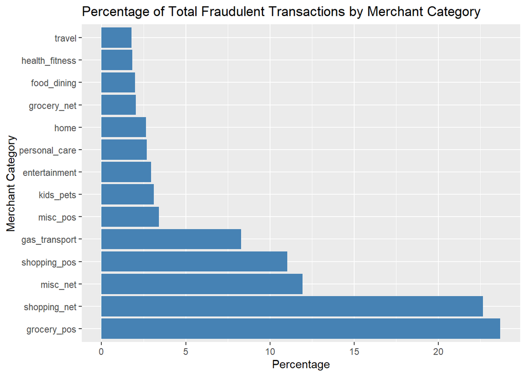

```r
# Display the bar chart
print(fraud_chart)
```

- When is fraud more prevalent? Which days, months, hours? To create new variables to help you in your analysis, we use the `lubridate` package and the following code

```
mutate(
  date_only = lubridate::date(trans_date_trans_time),
  month_name = lubridate::month(trans_date_trans_time, label=TRUE),
  hour = lubridate::hour(trans_date_trans_time),
  weekday = lubridate::wday(trans_date_trans_time, label = TRUE)
  )
```

```
  mutate(
   age = interval(dob, trans_date_trans_time) / years(1),
    )
```

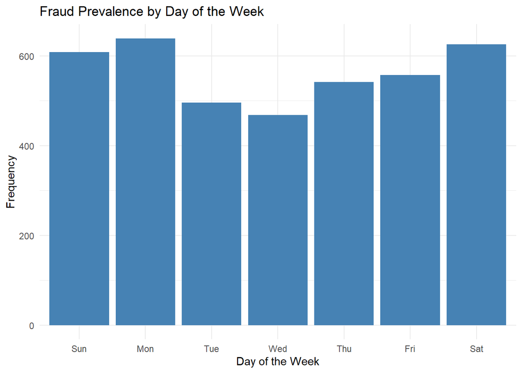

```r
library(lubridate)

time_updated_card_fraud<-card_fraud %>%
  mutate(
  date_only = lubridate::date(trans_date_trans_time),
  month_name = lubridate::month(trans_date_trans_time, label=TRUE),
  hour = lubridate::hour(trans_date_trans_time),
  weekday = lubridate::wday(trans_date_trans_time, label = TRUE)
  )

view(time_updated_card_fraud)

# Analyse fraud prevalence by day of the week
fraud_by_day <- time_updated_card_fraud %>%
  filter(is_fraud == 1) %>%
  group_by(weekday) %>%
  summarise(total_fraud = n()) %>%
  arrange(desc(total_fraud)) %>%
  ggplot(aes(x = weekday, y = total_fraud)) +
  geom_bar(stat = "identity", fill = "steelblue") +
  labs(x = "Day of the Week", y = "Frequency", title = "Fraud Prevalence by Day of the Week") +
  theme_minimal()

# Analyse fraud prevalence by month
fraud_by_month <- time_updated_card_fraud %>%
  filter(is_fraud == 1) %>%
  group_by(month_name) %>%
  summarise(total_fraud = n()) %>%
  arrange(desc(total_fraud)) %>%
  ggplot(aes(x = month_name, y = total_fraud)) +
  geom_bar(stat = "identity", fill = "steelblue") +
  labs(x = "Month", y = "Frequency", title = "Fraud Prevalence by month") +
  theme_minimal()

# Analyse fraud prevalence by hour
fraud_by_hour <- time_updated_card_fraud %>%
  filter(is_fraud == 1) %>%
  group_by(hour) %>%
  summarise(total_fraud = n()) %>%
  arrange(hour) %>%
  ggplot(aes(x = hour, y = total_fraud)) +
  geom_bar(stat = "identity", fill = "steelblue") +
  labs(x = "Hour of day", y = "Frequency", title = "Fraud Prevalence by Hour") +
  theme_minimal()

# Print the results
print(fraud_by_day)
```

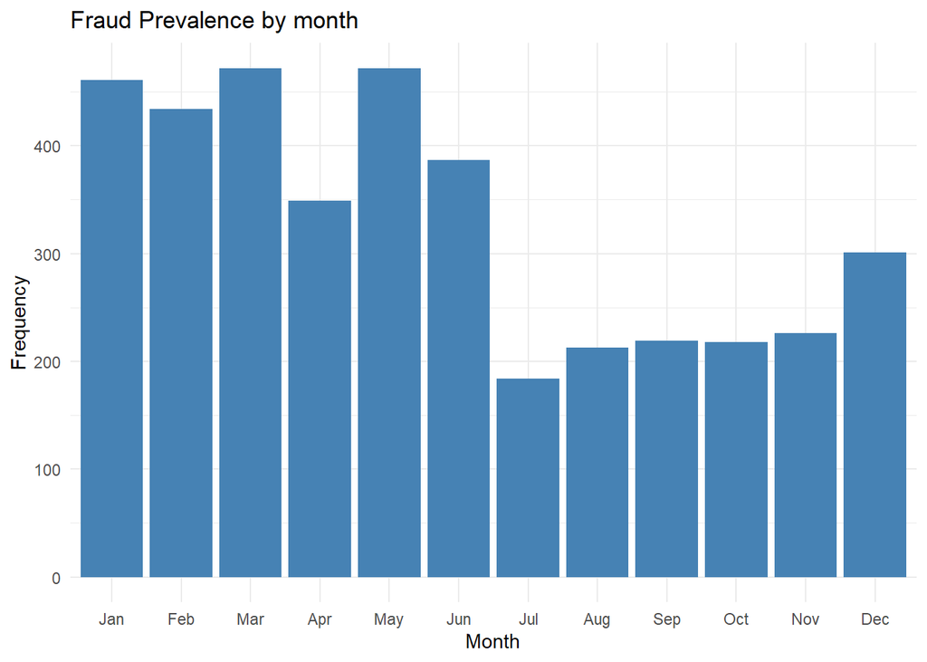

```r
print(fraud_by_month)
```

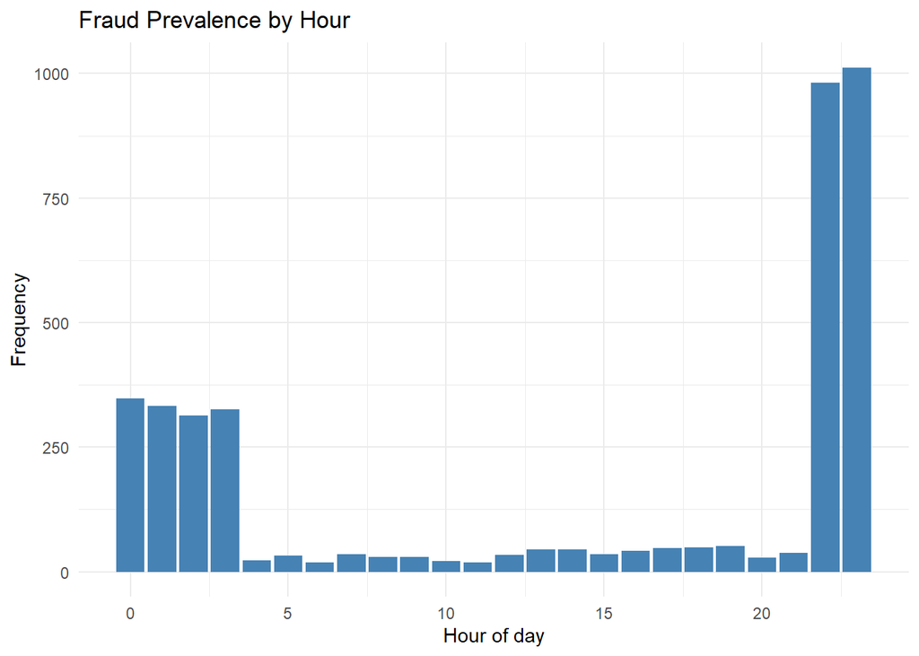

```r
print(fraud_by_hour)
```

# 3 Deliverables

There is a lot of explanatory text, comments, etc. You do not need these, so delete them and produce a stand-alone document that you could share with someone. Knit the edited and completed R Markdown (qmd) file as a Word or HTML document (use the “Knit” button at the top of the script editor window) and upload it to Canvas. You must be comitting and pushing your changes to your own Github repo as you go along.

# 4 Details

- Who did you collaborate with: Saagar Hemrajani, Chat GPT
- Approximately how much time did you spend on this problem set: 6 hours
- What, if anything, gave you the most trouble: The length and scope of the questions.

> As a true test to yourself, do you understand the code you submitted and are you able to explain it to someone else?